# Co2 Forecast

Using Prophet in Rstudio to produce a forecast for future co2 concentration

Adaan Antonjoe

15/03/2024

The purpose of this project is to be able to use prophet function to forecast future data for the co2(carbon dioxide) concentration in the atmosphere and see how prophet provides this data.

```r
library(prophet)
co2.dataframe = data.frame(
  ds=zoo::as.yearmon(time(co2)),
  y=co2)
```

The command install.packages(prophet) was used to download prophet.Then we create a data frame with columns of ds(time column) and y(data column) where the ds column are the dates and the y column is co2.Where co2 is the atmospheric concentration of carbon dioxide in the air. The code “?co2”provides more detail on the dataset.

```r
data_fitted<-prophet(co2.dataframe)
```

```
## Disabling weekly seasonality. Run prophet with weekly.seasonality=TRUE to override this.
```

```
## Disabling daily seasonality. Run prophet with daily.seasonality=TRUE to override this.
```

The prophet function here is used to fit the data.

```r
futureco2<-make_future_dataframe(data_fitted, periods=8,freq = "quarter" )
tail(futureco2)
```

```
##             ds
## 471 1998-09-01
## 472 1998-12-01
## 473 1999-03-01
## 474 1999-06-01
## 475 1999-09-01
## 476 1999-12-01
```

The make_future_dataframe takes the ds column containing the dates and makes predictions using the number of periods to create a suitable dataframe with additional dates. Here we can see the additional dates for 1999 split into quarters which are created from the function.

```r
forecastco2<-predict(data_fitted,futureco2)
```

The predict function is then used to create the forecast which is a data frame that contains the forecast within the yhat column.

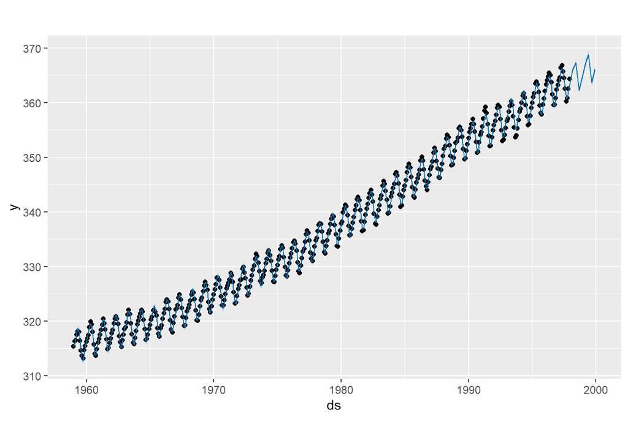

```r
plot(data_fitted,forecastco2)
```

Here we can plot the dates against the co2 concentration and the graph shows the predicted part for future using the forecast values. The blue line here shows the predicted values that prophet has produced.The black line is the original data.The graph shows that carbon dioxide concentration has been increasing however there is a lot of noise.

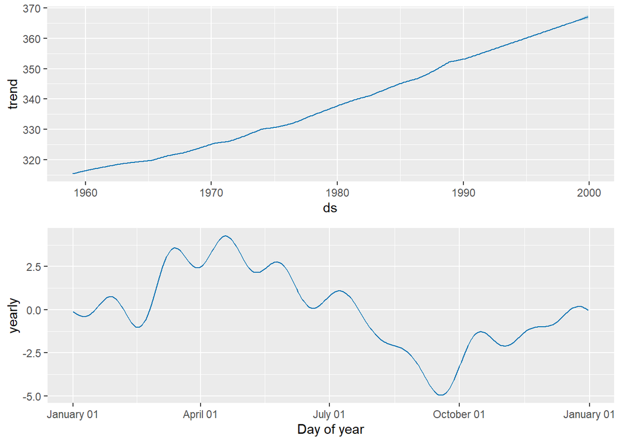

```r
prophet_plot_components(data_fitted,forecastco2,)
```

The yearly seasonality shows that in the first half of the year, especially in April there is a large increase before a drastic drop in late September.